# Notes 09: Principal Component Analysis

## Principal Component Analysis

Before we get started, let’s explore the data.

```r
places_orig <- read.csv("Places.csv") |> janitor::clean_names()
head(places_orig)
```

```
                   community climate housing_cost hlth_care crime transp educ
1                 Abilene,TX     521         6200       237   923   4031 2757
2                   Akron,OH     575         8138      1656   886   4883 2438
3                  Albany,GA     468         7339       618   970   2531 2560
4 Albany-Schenectady-Troy,NY     476         7908      1431   610   6883 3399
5             Albuquerque,NM     659         8393      1853  1483   6558 3026
6              Alexandria,LA     520         5819       640   727   2444 2972
  arts recreat econ case_num      long     lat    pop st_num
1  996    1405 7633        1  -99.6890 32.5590 110932     44
2 5564    2632 4350        2  -81.5180 41.0850 660328     36
3  237     859 5250        3  -84.1580 31.5750 112402     11
4 4655    1617 5864        4  -73.7983 42.7327 835880     35
5 4496    2612 5727        5 -106.6500 35.0830 419700     33
6  334    1018 5254        6  -92.4530 31.3020 135282     19
```

Graphs and summary statistics

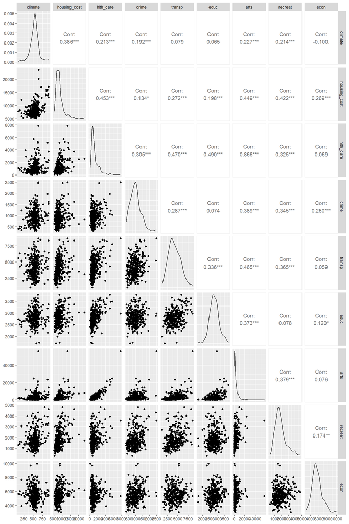

```r
places_orig |>
  select(climate, housing_cost, hlth_care, crime, transp, educ, arts, recreat, econ) |>
  GGally::ggpairs()
```

You might notice the scale of the variables is really different, so we might log transform our variables. We are only going to focus on 9 of the variables, which correspond to columns 2 through 10 (2:10)

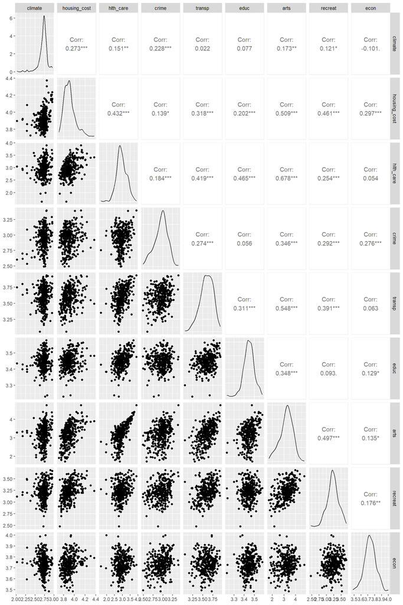

```r
#log transform the variables
places_log <- log10(places_orig[, 2:10])

places_log |>
  select(climate, housing_cost, hlth_care, crime, transp, educ, arts, recreat, econ) |>
  GGally::ggpairs()
```

We can calculate the variance of each variable this way.

```r
places_log |>
  summarize(across(1:9, var))
```

```
     climate housing_cost hlth_care     crime     transp        educ      arts
1 0.01289235   0.01111614 0.1027279 0.0286107 0.02482887 0.002519976 0.2971732
     recreat        econ
1 0.03530783 0.007136538
```

Here is the covariance matrix, correlation matrix, and variances for the variables.

```r
#correlation matrix
places_log |>
  corrr::correlate()  |> #correlation
  corrr::rearrange() #Re-arrange a correlation data frame to group highly correlated variables closer together.
```

```
# A tibble: 9 × 10
  term          econ climate   crime recreat housing_cost    educ  transp   arts
  <chr>        <dbl>   <dbl>   <dbl>   <dbl>        <dbl>   <dbl>   <dbl>  <dbl>
1 econ       NA      -0.101   0.276   0.176         0.297  0.129   0.0627  0.135
2 climate    -0.101  NA       0.228   0.121         0.273  0.0775  0.0216  0.173
3 crime       0.276   0.228  NA       0.292         0.139  0.0555  0.274   0.346
4 recreat     0.176   0.121   0.292  NA             0.461  0.0930  0.391   0.497
5 housing_c…  0.297   0.273   0.139   0.461        NA      0.202   0.318   0.509
6 educ        0.129   0.0775  0.0555  0.0930        0.202 NA       0.311   0.348
7 transp      0.0627  0.0216  0.274   0.391         0.318  0.311  NA       0.548
8 arts        0.135   0.173   0.346   0.497         0.509  0.348   0.548  NA
9 hlth_care   0.0540  0.151   0.184   0.254         0.432  0.465   0.419   0.678
# ℹ 1 more variable: hlth_care <dbl>
```

```r
#covariance matrix
places_log |>
  cov()  # covariance matrix
```

```
                   climate housing_cost   hlth_care        crime       transp
climate       0.0128923499  0.003267753 0.005479265 0.0043741176 0.0003857247
housing_cost  0.0032677528  0.011116141 0.014596210 0.0024830608 0.0052785799
hlth_care     0.0054792649  0.014596210 0.102727892 0.0099549524 0.0211534636
crime         0.0043741176  0.002483061 0.009954952 0.0286107020 0.0072989317
transp        0.0003857247  0.005278580 0.021153464 0.0072989317 0.0248288688
educ          0.0004415009  0.001069585 0.007477811 0.0004713186 0.0024618893
arts          0.0106885887  0.029226303 0.118484365 0.0319465684 0.0470407089
recreat       0.0025732595  0.009126983 0.015299431 0.0092846815 0.0115674940
econ         -0.0009661793  0.002645830 0.001463400 0.0039464274 0.0008343588
                     educ        arts     recreat          econ
climate      0.0004415009 0.010688589 0.002573259 -0.0009661793
housing_cost 0.0010695852 0.029226303 0.009126983  0.0026458304
hlth_care    0.0074778111 0.118484365 0.015299431  0.0014633998
crime        0.0004713186 0.031946568 0.009284681  0.0039464274
transp       0.0024618893 0.047040709 0.011567494  0.0008343588
educ         0.0025199764 0.009520409 0.000877247  0.0005464533
arts         0.0095204087 0.297173152 0.050859988  0.0062060281
recreat      0.0008772470 0.050859988 0.035307826  0.0027924140
econ         0.0005464533 0.006206028 0.002792414  0.0071365383
```

```r
# variances are extracted from the diagonal of the covariance matrix
places_log |>
  cov() |>
  diag() # variances
```

```
     climate housing_cost    hlth_care        crime       transp         educ
 0.012892350  0.011116141  0.102727892  0.028610702  0.024828869  0.002519976
        arts      recreat         econ
 0.297173152  0.035307826  0.007136538
```

## Total variance for all 9 variables

Ultimately what we will be doing for PCA is to determine components that explain some of the variance in our data. To calculate the proportion of variance accounted for by a single PC, we will need to determine the total variance of our data, which just happens to be the sum of all variances! See how this value matches the output from PCA total variance.

```r
places_log |>
  cov() |>
  diag() |>
  sum() |>
  round(4)
```

```
[1] 0.5223
```

## Fitting the PCs

There are several base R options for computing PCs, including `prcomp` and `princomp`. We will focus on `princomp` here, but the ISLR book has more information on `prcomp`.

```r
# cleaner code for when your data is just the columns you want. place_log only includes the 9 variables we are conducting PCA with, so we don't need to specify any variables in particular
fit <- princomp(~., data = places_log, cor = F, scores = T)

# this code does the same thing as above
fit <- princomp(places_log, cor = F, scores = T)
fit
```

```
Call:
princomp(x = places_log, cor = F, scores = T)

Standard deviations:
    Comp.1     Comp.2     Comp.3     Comp.4     Comp.5     Comp.6     Comp.7
0.61344524 0.22560372 0.16683741 0.15131845 0.12930691 0.10916208 0.09182048
    Comp.8     Comp.9
0.06262795 0.04233050

 9  variables and  329 observations.
```

```r
summary(fit)
```

```
Importance of components:
                          Comp.1     Comp.2    Comp.3     Comp.4     Comp.5
Standard deviation     0.6134452 0.22560372 0.1668374 0.15131845 0.12930691
Proportion of Variance 0.7226740 0.09774248 0.0534537 0.04397184 0.03210956
Cumulative Proportion  0.7226740 0.82041652 0.8738702 0.91784205 0.94995161
                           Comp.6     Comp.7      Comp.8      Comp.9
Standard deviation     0.10916208 0.09182048 0.062627954 0.042330504
Proportion of Variance 0.02288413 0.01619086 0.007532295 0.003441103
Cumulative Proportion  0.97283574 0.98902660 0.996558897 1.000000000
```

## Eigenvalues and Variances

Notice that the eigenvalues of the covariance matrix are the variances of the PCs, or the standard deviations squared and sum to the total variance.

```r
(eig_val <- fit$sdev^2) # PC standard deviations squared, or variance
```

```
     Comp.1      Comp.2      Comp.3      Comp.4      Comp.5      Comp.6
0.376315063 0.050897040 0.027834722 0.022897273 0.016720276 0.011916361
     Comp.7      Comp.8      Comp.9
0.008431000 0.003922261 0.001791872
```

```r
sum(eig_val) # sum of PC variances
```

```
[1] 0.5207259
```

```r
eigen(cov(places_log))$values # eigenvalues of the covariance matrix
```

```
[1] 0.377462365 0.051052214 0.027919584 0.022967082 0.016771253 0.011952691
[7] 0.008456704 0.003934219 0.001797335
```

```r
sum(eigen(cov(places_log))$values) # sum of eigen values
```

```
[1] 0.5223134
```

## Eigenvectors and Loadings

In addition, the eigenvectors are the same as the loadings for the PCs. Recall that we can transform the loadings by multiplying all loadings by -1 and it will provide the same results and interpretations.

```r
eigen(cov(places_log))$vectors
```

```
             [,1]         [,2]         [,3]         [,4]        [,5]
 [1,] -0.03507288 -0.008878199  0.140874773  0.152744763  0.39751159
 [2,] -0.09335159 -0.009230568  0.128849671 -0.178382332  0.17531330
 [3,] -0.40776448  0.858531872  0.276057691 -0.035161389  0.05032469
 [4,] -0.10044536 -0.220423717  0.592688202  0.723663035 -0.01345714
 [5,] -0.15009714 -0.059201112  0.220898162 -0.126205306 -0.86996951
 [6,] -0.03215319  0.060588578  0.008144704 -0.005196935 -0.04779772
 [7,] -0.87434057 -0.303806315 -0.363287318  0.081115715  0.05506994
 [8,] -0.15899622 -0.333992555  0.583626046 -0.628226088  0.21328989
 [9,] -0.01949418 -0.056101097  0.120853367  0.052169966  0.02965242
             [,6]        [,7]        [,8]         [,9]
 [1,]  0.83129501 -0.05590960 -0.31490125  0.064489248
 [2,]  0.20905725  0.69589230  0.61361583 -0.086877024
 [3,] -0.08967085 -0.06245284 -0.02103580  0.065503334
 [4,] -0.16401885 -0.05553037  0.18234790 -0.054212229
 [5,]  0.37244964  0.07246040 -0.05714199  0.071839419
 [6,]  0.02362804  0.05738567 -0.20447312 -0.973271069
 [7,] -0.02812147 -0.02326980 -0.01673991  0.005256563
 [8,] -0.14179906 -0.23451524 -0.08353911 -0.017494719
 [9,] -0.26481279  0.66448592 -0.66203179  0.168263765
```

```r
print(fit$loadings, cutoff = 0)
```

```
Loadings:
             Comp.1 Comp.2 Comp.3 Comp.4 Comp.5 Comp.6 Comp.7 Comp.8 Comp.9
climate       0.035  0.009  0.141  0.153  0.398  0.831  0.056  0.315  0.064
housing_cost  0.093  0.009  0.129 -0.178  0.175  0.209 -0.696 -0.614 -0.087
hlth_care     0.408 -0.859  0.276 -0.035  0.050 -0.090  0.062  0.021  0.066
crime         0.100  0.220  0.593  0.724 -0.013 -0.164  0.056 -0.182 -0.054
transp        0.150  0.059  0.221 -0.126 -0.870  0.372 -0.072  0.057  0.072
educ          0.032 -0.061  0.008 -0.005 -0.048  0.024 -0.057  0.204 -0.973
arts          0.874  0.304 -0.363  0.081  0.055 -0.028  0.023  0.017  0.005
recreat       0.159  0.334  0.584 -0.628  0.213 -0.142  0.235  0.084 -0.017
econ          0.019  0.056  0.121  0.052  0.030 -0.265 -0.664  0.662  0.168

               Comp.1 Comp.2 Comp.3 Comp.4 Comp.5 Comp.6 Comp.7 Comp.8 Comp.9
SS loadings     1.000  1.000  1.000  1.000  1.000  1.000  1.000  1.000  1.000
Proportion Var  0.111  0.111  0.111  0.111  0.111  0.111  0.111  0.111  0.111
Cumulative Var  0.111  0.222  0.333  0.444  0.556  0.667  0.778  0.889  1.000
```

## Visualizing PCs

We have two options for visualizing our PCs. One is the Scree plot, used to make decisions about dimension reduction, and the other is the biplot, used to explore the data further.

Here is the scree plot:

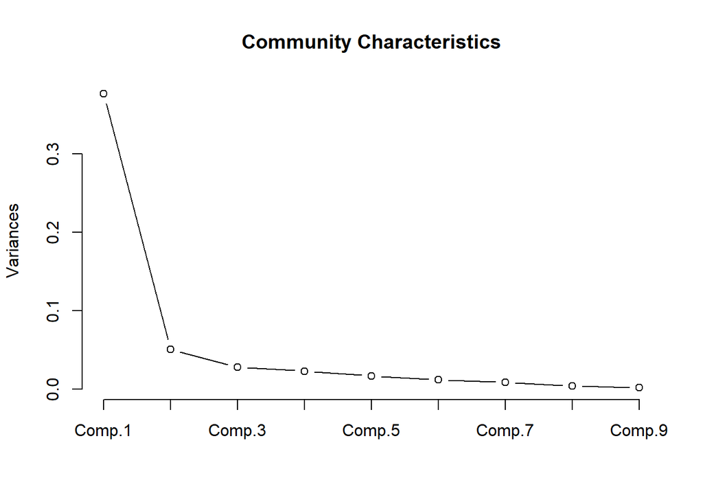

```r
screeplot(fit, type = "lines", main = "Community Characteristics")
```

## PC Scores (fits) and Regression

We can extract the calculated PC values for each observation in our data by extracting `$scores`. We can further specify which PCs we want by indicating specific column numbers.

```r
fit$scores[, 1] # PC 1
fit$scores[, 3:4] # PCs 3 and 4
```

If we just want the first 25 rows of the PCs 1:5, here they are:

```r
fit$scores[1:25, 1:5]
```

```
            Comp.1       Comp.2       Comp.3       Comp.4       Comp.5
 [1,] -0.436677074  0.420163405 -0.118120947  0.089958799 -0.080968263
 [2,]  0.620957601  0.005345798  0.001808156 -0.100744859  0.021649721
 [3,] -0.873256319 -0.212103638  0.049692893  0.171611664  0.026653658
 [4,]  0.502948082 -0.063621453 -0.170494934 -0.112302567 -0.196313208
 [5,]  0.609775036 -0.007232627  0.233126672  0.050233910 -0.071192495
 [6,] -0.745633249 -0.188182770 -0.040752397  0.072765141  0.063687246
 [7,]  0.005097109  0.063496453 -0.378155444 -0.025016123  0.095842485
 [8,] -0.039375963 -0.092385376 -0.095279126  0.004403922 -0.123508845
 [9,] -0.893575198 -0.097861687 -0.107067674 -0.201101362 -0.124010585
[10,] -0.164904064  0.041771531 -0.027938414  0.184347472 -0.122069904
[11,]  0.703776040 -0.028148235  0.160214871 -0.124947030  0.249835313
[12,]  0.143875264  0.331744286  0.122791383 -0.142450812 -0.175186957
[13,] -0.668842631 -0.130163191 -0.101824939  0.180023322 -0.011697939
[14,] -0.977440004 -0.416159984  0.048922458  0.275183599 -0.014898105
[15,]  0.802625339 -0.126636773 -0.000646199 -0.006770290  0.165301640
[16,] -0.804526312 -0.119289184  0.148785355  0.161478743 -0.003022958
[17,] -0.154621973 -0.024371022 -0.052870634 -0.271444957  0.041119217
[18,] -0.016238960 -0.179200140 -0.053784756 -0.111055726 -0.064798103
[19,]  0.139749114  0.162881937 -0.370517439  0.253422823  0.255777681
[20,]  0.870728224 -0.239600454  0.050943944  0.191316093 -0.190601057
[21,] -0.345375150  0.152141581  0.458344389  0.076301944  0.105764692
[22,] -0.122784742 -0.418409897 -0.067232733  0.178856845  0.101788316
[23,]  0.388620116  0.014954733 -0.105337936 -0.045215136  0.041243304
[24,]  0.406486994  0.163683164 -0.279365746  0.212257562 -0.012515937
[25,] -0.223536863  0.295596586  0.080464988  0.207252230  0.004392704
```

```r
cor(places_log$climate, fit$scores[, 1]) # just for climate
```

```
[1] 0.1897764
```

```r
cor(places_log, fit$scores[, 1:5]) # correlations for all variables in places and PCs 1:5
```

```
                Comp.1      Comp.2      Comp.3      Comp.4      Comp.5
climate      0.1897764  0.01766713  0.20731067  0.20386994  0.45338433
housing_cost 0.5439783  0.01978148  0.20420236 -0.25640573  0.21533796
hlth_care    0.7816315 -0.60522871  0.14391635 -0.01662550  0.02033385
crime        0.3648400  0.29444308  0.58548598  0.64837318 -0.01030318
transp       0.5852356  0.08489042  0.23424380 -0.12138138 -0.71500374
educ         0.3935162 -0.27270921  0.02711012 -0.01568924 -0.12330813
arts         0.9854003  0.12592133 -0.11135249  0.02255034  0.01308255
recreat      0.5198621  0.40161376  0.51898362 -0.50667957  0.14700006
econ         0.1417745  0.15004960  0.23903937  0.09359005  0.04545682
```

## Standardized Variables

In many situations, we will want to standardize the variables of interest to account for different units of measurement and magnitudes that can unduly influnece the PC construction. This is simple, we can do this by setting `cor=TRUE` in our `princomp` function.

```r
fit_corr <- princomp(places_log, cor = T, scores = T)
fit_corr
```

```
Call:
princomp(x = places_log, cor = T, scores = T)

Standard deviations:
   Comp.1    Comp.2    Comp.3    Comp.4    Comp.5    Comp.6    Comp.7    Comp.8
1.8159827 1.1016178 1.0514418 0.9525124 0.9277008 0.7497905 0.6955721 0.5639789
   Comp.9
0.5011269

 9  variables and  329 observations.
```

```r
summary(fit_corr)
```

```
Importance of components:
                          Comp.1    Comp.2    Comp.3    Comp.4     Comp.5
Standard deviation     1.8159827 1.1016178 1.0514418 0.9525124 0.92770076
Proportion of Variance 0.3664214 0.1348402 0.1228367 0.1008089 0.09562541
Cumulative Proportion  0.3664214 0.5012617 0.6240983 0.7249072 0.82053259
                           Comp.6     Comp.7     Comp.8     Comp.9
Standard deviation     0.74979050 0.69557215 0.56397886 0.50112689
Proportion of Variance 0.06246509 0.05375785 0.03534135 0.02790313
Cumulative Proportion  0.88299767 0.93675552 0.97209687 1.00000000
```

```r
#default print is to suppress loadings close to 0
print(fit_corr$loadings)
```

```
Loadings:
             Comp.1 Comp.2 Comp.3 Comp.4 Comp.5 Comp.6 Comp.7 Comp.8 Comp.9
climate       0.158         0.800  0.377         0.217  0.151  0.341
housing_cost  0.384  0.139         0.197 -0.580         0.275 -0.606
hlth_care     0.410 -0.372         0.113        -0.535 -0.135  0.150  0.594
crime         0.259  0.474  0.128         0.692 -0.140 -0.110 -0.420
transp        0.375 -0.141 -0.141 -0.430  0.191  0.324  0.679  0.119  0.136
educ          0.274 -0.452 -0.241  0.457  0.225  0.527 -0.262 -0.211 -0.110
arts          0.474 -0.104        -0.147        -0.321 -0.120  0.260 -0.747
recreat       0.353  0.292        -0.404 -0.306  0.394 -0.553  0.138  0.226
econ          0.164  0.540 -0.507  0.476                0.147  0.415

               Comp.1 Comp.2 Comp.3 Comp.4 Comp.5 Comp.6 Comp.7 Comp.8 Comp.9
SS loadings     1.000  1.000  1.000  1.000  1.000  1.000  1.000  1.000  1.000
Proportion Var  0.111  0.111  0.111  0.111  0.111  0.111  0.111  0.111  0.111
Cumulative Var  0.111  0.222  0.333  0.444  0.556  0.667  0.778  0.889  1.000
```

```r
#print the loadings, showing all values
print(fit_corr$loadings, cutoff = 0)
```

```
Loadings:
             Comp.1 Comp.2 Comp.3 Comp.4 Comp.5 Comp.6 Comp.7 Comp.8 Comp.9
climate       0.158  0.069  0.800  0.377  0.041  0.217  0.151  0.341  0.030
housing_cost  0.384  0.139  0.080  0.197 -0.580 -0.082  0.275 -0.606 -0.042
hlth_care     0.410 -0.372 -0.019  0.113  0.030 -0.535 -0.135  0.150  0.594
crime         0.259  0.474  0.128 -0.042  0.692 -0.140 -0.110 -0.420  0.051
transp        0.375 -0.141 -0.141 -0.430  0.191  0.324  0.679  0.119  0.136
educ          0.274 -0.452 -0.241  0.457  0.225  0.527 -0.262 -0.211 -0.110
arts          0.474 -0.104  0.011 -0.147  0.012 -0.321 -0.120  0.260 -0.747
recreat       0.353  0.292  0.042 -0.404 -0.306  0.394 -0.553  0.138  0.226
econ          0.164  0.540 -0.507  0.476 -0.037 -0.001  0.147  0.415  0.048

               Comp.1 Comp.2 Comp.3 Comp.4 Comp.5 Comp.6 Comp.7 Comp.8 Comp.9
SS loadings     1.000  1.000  1.000  1.000  1.000  1.000  1.000  1.000  1.000
Proportion Var  0.111  0.111  0.111  0.111  0.111  0.111  0.111  0.111  0.111
Cumulative Var  0.111  0.222  0.333  0.444  0.556  0.667  0.778  0.889  1.000
```

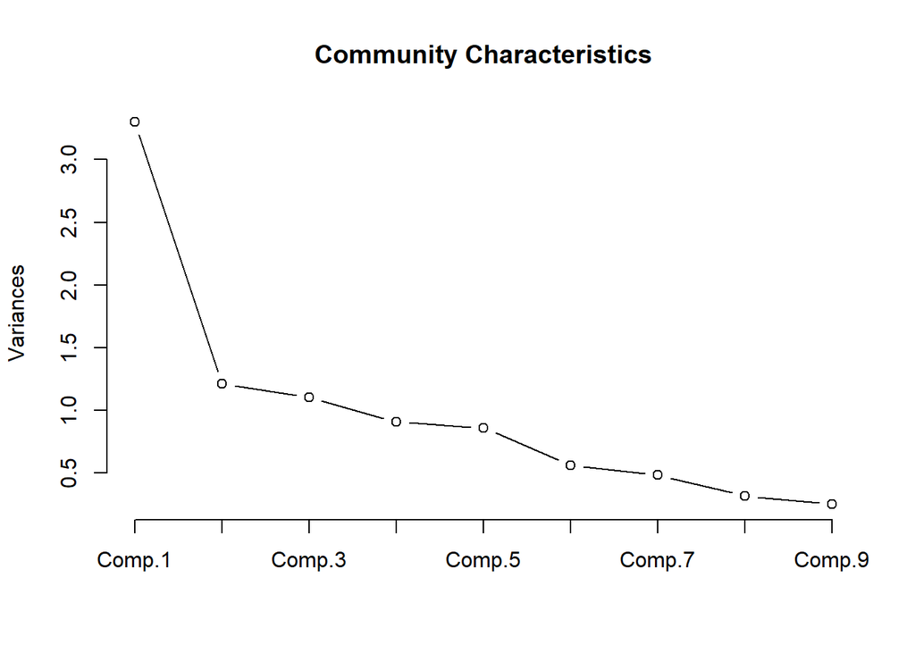

```r
screeplot(fit_corr, type = "lines", main = "Community Characteristics")
```

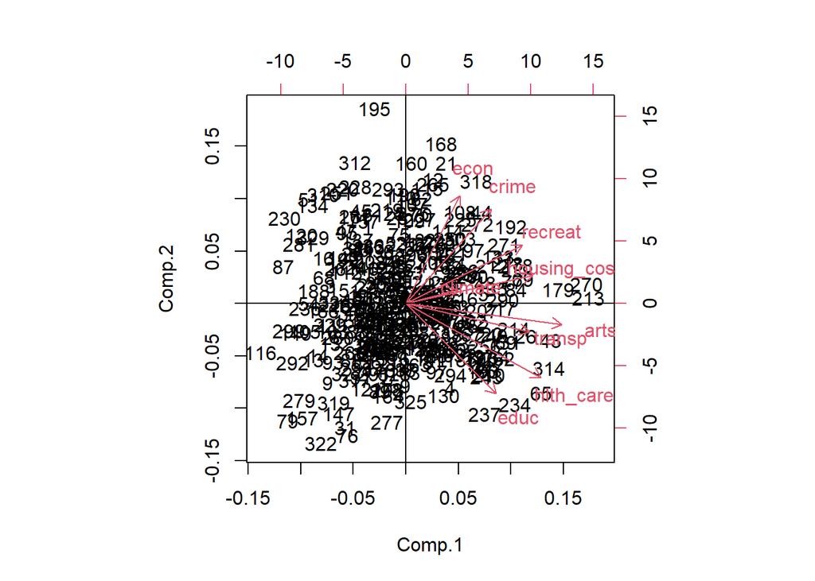

```r
biplot(fit_corr)
abline(h = 0)
abline(v = 0)
```

Note: it doesn’t matter if you calculate the correlation between the standardized or unstandardized variable and the PC based on standardized variables because correaltion is unitless.

```r
cor(scale(places_log$climate), fit_corr$scores)
```

```
        Comp.1     Comp.2    Comp.3    Comp.4     Comp.5    Comp.6   Comp.7
[1,] 0.2868188 0.07560335 0.8408485 0.3589157 0.03807829 0.1624758 0.105276
        Comp.8     Comp.9
[1,] 0.1923891 0.01508269
```

```r
cor((places_log$arts), fit_corr$scores[,1])
```

```
[1] 0.860498
```

The eigenvalues and eigenvectors now correspond to the **correlation** matrix and not the covariance matrix

```r
(eig_val <- fit_corr$sdev^2) # PC standard deviations squared, or variance
```

```
   Comp.1    Comp.2    Comp.3    Comp.4    Comp.5    Comp.6    Comp.7    Comp.8
3.2977930 1.2135619 1.1055299 0.9072798 0.8606287 0.5621858 0.4838206 0.3180722
   Comp.9
0.2511282
```

```r
sum(eig_val) # sum of PC variances
```

```
[1] 9
```

```r
eigen(cor(places_log))$values # eigenvalues of the covariance matrix
```

```
[1] 3.2977930 1.2135619 1.1055299 0.9072798 0.8606287 0.5621858 0.4838206
[8] 0.3180722 0.2511282
```

```r
sum(eigen(cor(places_log))$values) # sum of eigen values
```

```
[1] 9
```

```r
eigen(cor(places_log))$vectors
```

```
            [,1]        [,2]        [,3]        [,4]        [,5]          [,6]
 [1,] -0.1579414 -0.06862938  0.79970997  0.37680952 -0.04104588 -0.2166949681
 [2,] -0.3844053 -0.13920883  0.07961647  0.19654301  0.57986793  0.0822200812
 [3,] -0.4099096  0.37181203 -0.01947537  0.11252206 -0.02956935  0.5348756017
 [4,] -0.2591017 -0.47413246  0.12846722 -0.04229962 -0.69217100  0.1399009169
 [5,] -0.3748890  0.14148642 -0.14106828 -0.43007675 -0.19141608 -0.3238913974
 [6,] -0.2743254  0.45235526 -0.24105584  0.45694297 -0.22474374 -0.5265827320
 [7,] -0.4738471  0.10441020  0.01102628 -0.14688130 -0.01193024  0.3210570706
 [8,] -0.3534118 -0.29194243  0.04181639 -0.40401889  0.30565371 -0.3941387718
 [9,] -0.1640135 -0.54045312 -0.50731026  0.47578009  0.03710776  0.0009737383
            [,7]       [,8]        [,9]
 [1,]  0.1513516  0.3411282  0.03009755
 [2,]  0.2751971 -0.6061010 -0.04226906
 [3,] -0.1349750  0.1500575  0.59412763
 [4,] -0.1095036 -0.4201255  0.05101188
 [5,]  0.6785670  0.1188325  0.13584327
 [6,] -0.2620958 -0.2111749 -0.11012420
 [7,] -0.1204986  0.2598673 -0.74672678
 [8,] -0.5530938  0.1377181  0.22636544
 [9,]  0.1468669  0.4147736  0.04790278
```

```r
print(fit_corr$loadings, cutoff = 0)
```

```
Loadings:
             Comp.1 Comp.2 Comp.3 Comp.4 Comp.5 Comp.6 Comp.7 Comp.8 Comp.9
climate       0.158  0.069  0.800  0.377  0.041  0.217  0.151  0.341  0.030
housing_cost  0.384  0.139  0.080  0.197 -0.580 -0.082  0.275 -0.606 -0.042
hlth_care     0.410 -0.372 -0.019  0.113  0.030 -0.535 -0.135  0.150  0.594
crime         0.259  0.474  0.128 -0.042  0.692 -0.140 -0.110 -0.420  0.051
transp        0.375 -0.141 -0.141 -0.430  0.191  0.324  0.679  0.119  0.136
educ          0.274 -0.452 -0.241  0.457  0.225  0.527 -0.262 -0.211 -0.110
arts          0.474 -0.104  0.011 -0.147  0.012 -0.321 -0.120  0.260 -0.747
recreat       0.353  0.292  0.042 -0.404 -0.306  0.394 -0.553  0.138  0.226
econ          0.164  0.540 -0.507  0.476 -0.037 -0.001  0.147  0.415  0.048

               Comp.1 Comp.2 Comp.3 Comp.4 Comp.5 Comp.6 Comp.7 Comp.8 Comp.9
SS loadings     1.000  1.000  1.000  1.000  1.000  1.000  1.000  1.000  1.000
Proportion Var  0.111  0.111  0.111  0.111  0.111  0.111  0.111  0.111  0.111
Cumulative Var  0.111  0.222  0.333  0.444  0.556  0.667  0.778  0.889  1.000
```

One more note: correlation between vars and PCs is [loadings/eigenvalues * sqrt(eigenvalue)]

```r
cor((places_log), (fit_corr$scores[, 1:5]))
```

```
                Comp.1      Comp.2      Comp.3      Comp.4      Comp.5
climate      0.2868188  0.07560335  0.84084849  0.35891574  0.03807829
housing_cost 0.6980733  0.15335494  0.08371209  0.18720965 -0.53794392
hlth_care    0.7443888 -0.40959477 -0.02047721  0.10717865  0.02743151
crime        0.4705242  0.52231278  0.13507581 -0.04029091  0.64212756
transp       0.6807920 -0.15586396 -0.14832509 -0.40965343  0.17757684
educ         0.4981701 -0.49832263 -0.25345619  0.43524384  0.20849493
arts         0.8604980 -0.11502014  0.01159349 -0.13990625  0.01106769
recreat      0.6417896  0.32160899  0.04396750 -0.38483299 -0.28355518
econ         0.2978456  0.59537280 -0.53340722  0.45318643 -0.03442489
```

```r
-eigen(cor(places_log))$vectors[, 1:5] * sqrt(eigen(cor(places_log))$values[1:5])
```

```
           [,1]        [,2]        [,3]        [,4]        [,5]
 [1,] 0.2868188  0.06366753 -0.76173365 -0.39619329  0.04521687
 [2,] 0.4234677  0.25280083 -0.07386026 -0.18720965 -0.60969739
 [3,] 0.4309961 -0.40959477  0.03536693 -0.10438680  0.02816517
 [4,] 0.2467976  0.49852269 -0.14152178  0.07681537  0.64212756
 [5,] 0.3477848 -0.13476756  0.14832509  0.47378022  0.34760827
 [6,] 0.4981701 -0.41965032  0.22960868 -0.48044894  0.24758171
 [7,] 0.5219984 -0.18960712 -0.01022909  0.13990625  0.01254395
 [8,] 0.3715919  0.32160899 -0.07593783  0.37480863 -0.29113895
 [9,] 0.1562248  0.56825500  0.55886204 -0.86400839 -0.03442489
```

## Regression and PCA

```r
cars <- read.csv("Cars.csv")
summary(cars)
```

```
     Price          LnPrice          Mileage           Cyl
 Min.   : 8639   Min.   : 9.064   Min.   :  266   Min.   :4.000
 1st Qu.:14273   1st Qu.: 9.566   1st Qu.:14624   1st Qu.:4.000
 Median :18025   Median : 9.800   Median :20914   Median :6.000
 Mean   :21343   Mean   : 9.879   Mean   :19832   Mean   :5.269
 3rd Qu.:26717   3rd Qu.:10.193   3rd Qu.:25213   3rd Qu.:6.000
 Max.   :70755   Max.   :11.167   Max.   :50387   Max.   :8.000
     Liter           Buick           Cadillac        Chevrolet
 Min.   :1.600   Min.   :0.0000   Min.   :0.0000   Min.   :0.000
 1st Qu.:2.200   1st Qu.:0.0000   1st Qu.:0.0000   1st Qu.:0.000
 Median :2.800   Median :0.0000   Median :0.0000   Median :0.000
 Mean   :3.037   Mean   :0.0995   Mean   :0.0995   Mean   :0.398
 3rd Qu.:3.800   3rd Qu.:0.0000   3rd Qu.:0.0000   3rd Qu.:1.000
 Max.   :6.000   Max.   :1.0000   Max.   :1.0000   Max.   :1.000
    Pontiac            SAAB            Saturn            Doors
 Min.   :0.0000   Min.   :0.0000   Min.   :0.00000   Min.   :2.000
 1st Qu.:0.0000   1st Qu.:0.0000   1st Qu.:0.00000   1st Qu.:4.000
 Median :0.0000   Median :0.0000   Median :0.00000   Median :4.000
 Mean   :0.1866   Mean   :0.1418   Mean   :0.07463   Mean   :3.527
 3rd Qu.:0.0000   3rd Qu.:0.0000   3rd Qu.:0.00000   3rd Qu.:4.000
 Max.   :1.0000   Max.   :1.0000   Max.   :1.00000   Max.   :4.000
     Cruise           Sound           Leather           Make
 Min.   :0.0000   Min.   :0.0000   Min.   :0.0000   Length:804
 1st Qu.:1.0000   1st Qu.:0.0000   1st Qu.:0.0000   Class :character
 Median :1.0000   Median :1.0000   Median :1.0000   Mode  :character
 Mean   :0.7525   Mean   :0.6791   Mean   :0.7239
 3rd Qu.:1.0000   3rd Qu.:1.0000   3rd Qu.:1.0000
 Max.   :1.0000   Max.   :1.0000   Max.   :1.0000
    Model               Trim               Type
 Length:804         Length:804         Length:804
 Class :character   Class :character   Class :character
 Mode  :character   Mode  :character   Mode  :character
```

For the Cars data, we want to predict a car’s price based on its other characteristics. Let’s look at basic linear regression for this situation.

```r
library(car)
model <- lm(LnPrice ~ Mileage + Cyl + Liter + factor(Buick) + factor(Cadillac) + factor(Chevrolet) + factor(Pontiac) + factor(SAAB), data = cars)
summary(model)
```

```
Call:
lm(formula = LnPrice ~ Mileage + Cyl + Liter + factor(Buick) +
    factor(Cadillac) + factor(Chevrolet) + factor(Pontiac) +
    factor(SAAB), data = cars)

Residuals:
     Min       1Q   Median       3Q      Max
-0.31867 -0.07530 -0.00903  0.05960  0.42687

Coefficients:
                     Estimate Std. Error t value Pr(>|t|)
(Intercept)         9.232e+00  3.275e-02 281.922  < 2e-16 ***
Mileage            -8.020e-06  5.108e-07 -15.701  < 2e-16 ***
Cyl                -3.642e-02  1.337e-02  -2.725  0.00657 **
Liter               2.683e-01  1.492e-02  17.980  < 2e-16 ***
factor(Buick)1      1.013e-01  2.137e-02   4.740 2.54e-06 ***
factor(Cadillac)1   6.099e-01  2.589e-02  23.556  < 2e-16 ***
factor(Chevrolet)1 -1.803e-02  1.687e-02  -1.068  0.28563
factor(Pontiac)1    4.005e-02  1.888e-02   2.121  0.03423 *
factor(SAAB)1       7.901e-01  1.898e-02  41.637  < 2e-16 ***
---
Signif. codes:  0 '***' 0.001 '**' 0.01 '*' 0.05 '.' 0.1 ' ' 1

Residual standard error: 0.1183 on 795 degrees of freedom
Multiple R-squared:  0.9176,    Adjusted R-squared:  0.9168
F-statistic:  1107 on 8 and 795 DF,  p-value: < 2.2e-16
```

```r
vif(model)
```

```
          Mileage               Cyl             Liter     factor(Buick)
         1.006034         19.739176         15.623827          2.352013
 factor(Cadillac) factor(Chevrolet)   factor(Pontiac)      factor(SAAB)
         3.451443          3.920979          3.110392          2.518130
```

We can construct PCs just for the collinear variables

```r
fit_car <- princomp(cbind(cars$Cyl, cars$Liter), cor = T, scores = T)
summary(fit_car)
```

```
Importance of components:
                          Comp.1     Comp.2
Standard deviation     1.3992486 0.20519118
Proportion of Variance 0.9789483 0.02105171
Cumulative Proportion  0.9789483 1.00000000
```

```r
fit_car$loadings
```

```
Loadings:
     Comp.1 Comp.2
[1,]  0.707  0.707
[2,]  0.707 -0.707

               Comp.1 Comp.2
SS loadings       1.0    1.0
Proportion Var    0.5    0.5
Cumulative Var    0.5    1.0
```

```r
model_pca <- lm(LnPrice ~ Mileage + fit_car$scores[, 1] + factor(Buick) + factor(Cadillac) + factor(Chevrolet) + factor(Pontiac) + factor(SAAB), data = cars)
summary(model_pca)
```

```
Call:
lm(formula = LnPrice ~ Mileage + fit_car$scores[, 1] + factor(Buick) +
    factor(Cadillac) + factor(Chevrolet) + factor(Pontiac) +
    factor(SAAB), data = cars)

Residuals:
     Min       1Q   Median       3Q      Max
-0.29009 -0.08785 -0.01405  0.07250  0.39217

Coefficients:
                      Estimate Std. Error t value Pr(>|t|)
(Intercept)          9.874e+00  1.997e-02 494.336  < 2e-16 ***
Mileage             -7.954e-06  5.418e-07 -14.682  < 2e-16 ***
fit_car$scores[, 1]  1.886e-01  4.072e-03  46.317  < 2e-16 ***
factor(Buick)1       7.652e-02  2.252e-02   3.398 0.000712 ***
factor(Cadillac)1    4.933e-01  2.454e-02  20.103  < 2e-16 ***
factor(Chevrolet)1  -2.734e-02  1.787e-02  -1.530 0.126457
factor(Pontiac)1     1.487e-02  1.985e-02   0.749 0.454022
factor(SAAB)1        8.071e-01  2.005e-02  40.257  < 2e-16 ***
---
Signif. codes:  0 '***' 0.001 '**' 0.01 '*' 0.05 '.' 0.1 ' ' 1

Residual standard error: 0.1255 on 796 degrees of freedom
Multiple R-squared:  0.9072,    Adjusted R-squared:  0.9064
F-statistic:  1112 on 7 and 796 DF,  p-value: < 2.2e-16
```

```r
vif(model_pca)
```

```
            Mileage fit_car$scores[, 1]       factor(Buick)    factor(Cadillac)
           1.005866            1.658128            2.320576            2.756084
  factor(Chevrolet)     factor(Pontiac)        factor(SAAB)
           3.909111            3.055403            2.498125
```

Collinearity is no longer an issue!

## Standardizing variables - Example Simulation

```r
a <- rnorm(100, 5, 2)
b <- rnorm(100, 100, 2)
c <- rnorm(100, 500, 40)



center_a <- a - mean(a)
center_b <- b- mean(b)
center_c <- c - mean(c)

st_a <- (a - mean(a))/sd(a)
st_b <- (b - mean(b))/sd(b)
mean(st_a)
```

```
[1] -1.845746e-17
```

```r
var(st_a)
```

```
[1] 1
```

```r
var(st_b)
```

```
[1] 1
```

```r
var(center_c)
```

```
[1] 1552.637
```